# Wearing a red uniform shortens lifespan in Starfleet officers

Damn it, man, I’m a doctor, not an undertaker!

Leonard H. McCoy https://memory-alpha.fandom.com/wiki/Leonard_McCoy (Starfleet)https://memory-alpha.fandom.com/wiki/Starfleet , S’chn T’gal Spock https://memory-alpha.fandom.com/wiki/Spock (Starfleet)https://memory-alpha.fandom.com/wiki/Starfleet  
02-13-2287

# Introduction

> “Enterprise Medical Log, Stardate 5327.4. Dr. Leonard McCoy recording. Captain Kirk and First Officer Spock were rescued 48 hours ago, along with several deceased members of the away team. They do not know why the creature ignored them during the attack, but I have my suspicions. The victims were all wearing red shirts.”—McCoy (5327)

I am haunted by an uncomfortable reality: Over the past several weeks the number of deaths I have listed on the *Enterprise*[^1] is growing, and no matter the circumstance they all share one thing in common—each and every one of them wore a red uniform. I approached First Officer Spock with my concerns, but he brushed me off as thinking with undue emotions. Our operations division wears red uniforms, so this pattern of deaths was “logical” (Spock, 2287).

Despite that damn Vulcan’s logic, he could not explain why himself and Captain Kirk had not yet suffered similar fates. I can find no reason why they are still alive, except, possibly, that the colour of their uniforms is somehow involved. Although improbable, it is the only hypothesis I have. Captain Kirk has employed Spock and I to conduct a study to investigate.

The aim of our study is simple: We will test whether the uniform colour of Starfleet officers on board the Enterprise cause them to suffer more severe injuries during away missions. I hypothesize that, regardless of their division, officers wearing red uniforms will suffer more severe injuries. Spock states that this is illogical, and hypothesizes that members of the operations division will continue to suffer more severe injuries no matter their uniform colour.

# Methodology

## Participants

423 Starfleet officers on board the starship Enterprise participated in our study, 305 of which identified as men ($\mathit{M_{age}} = 35.53$, $\mathit{SD_{age}} = 11.27$) and 118 as women ($\mathit{M_{age}} = 36.21$, $\mathit{SD_{age}} = 11.51$). Myself, First Officer Spock, and Captain Kirk did not participate in the study. Six redshirts who were supposed to participate were excluded from the study. A can be seen in Figure 1, Captain Kirk foolishly sent them on an away mission; we have lost all contact since.

[figure not shown]

Figure 1: Captain Kirk sending a team of redshirts on an away mission to the Klingon supermarkets on Qo’noS.

## Design

We used a 3x3 independent design to test our hypotheses, with division (science/medical, command, operations) and uniform colour (blue, yellow, red) as independent variables. The Starfleet designations for divisions and their uniform colours can be seen in Figure 2. Severity of injury—our dependent variable—was measured on a 10-point scale developed by Phlox (2153), where one represented the lowest severity and ten the highest. Examples of lower severity injuries include broken bones, cellular damage, or curable infections obtained during copulation with an alien species. Higher severity injuries include decapitation by Bat’leth, exposure to delta-particle radiation, or being crushed by Tribbles.[^2]

[figure not shown]

Figure 2: Depiction of Starfleet divisions and their respective uniform colours.

## Procedure

Our procedure was simple, although imperfect as First Officer Spock wants us to remind you. Each Starfleet officer was randomly assigned a uniform colour they were to wear over a one month period, however, they remained within their current division due to operational constraints. Aside from this, each officer continued with their regular duties aboard the Enterprise. My medical team and I then recorded the severity of injury, division, and uniform colour for any patients that came into sickbay during the study period. Patients with multiple visits had their severity of injury scores averaged at the end of the period so their was only one score per participant.

# Results

## Two-way ANOVA assumptions

Table 1: Table Showing Assumption of Normality Tests.

| **Cell** | **Skewness** | **Kurtosis** | *W* | *df* | *p* |
| --- | --- | --- | --- | --- | --- |
| Command Blue | 0.09 | 2.62 | 0.95 | 47 | .062 |
| Command Red | -0.09 | 2.37 | 0.93 | 47 | .010 |
| Command Yellow | -0.04 | 2.63 | 0.95 | 47 | .052 |
| Operations Blue | 0.21 | 2.75 | 0.93 | 47 | .008 |
| Operations Red | -0.49 | 2.73 | 0.92 | 47 | .002 |
| Operations Yellow | -0.39 | 2.30 | 0.93 | 47 | .010 |
| Science Medical Blue | -0.22 | 2.67 | 0.95 | 47 | .029 |
| Science Medical Red | -0.13 | 2.78 | 0.94 | 47 | .027 |
| Science Medical Yellow | 0.21 | 2.55 | 0.94 | 47 | .021 |

## Two-way ANOVA results

There was no significant main effect of division, $F(2, 414) = 1.23$, $p = .292$, $\omega^2_p = .001$, nor was there a significant interaction effect, $F(4, 414) = 1.64$, $p = .163$, $\omega^2_p = .006$. In support of my hypothesis (and in contempt of Spock’s), there was a significant main effect of uniform colour on severity of injury, $F(2, 414) = 352.20$, $p < .001$, $\omega^2_p = .624$. This indicates different uniform colours affected the severity of injuries Starfleet officers suffered. Specifically, post-hoc pairwise comparisons corrected using the Tukey method found that officers wearing red uniforms ($\mathit{M} = 7.85$, $\mathit{SD} = 1.37$) suffered significantly worse injuries than officers wearing blue uniforms ($\mathit{M} = 4.00$, $\mathit{SD} = 1.32$), $t(414) = 23.26$, $p_{\mathit{adj}} < .001$, $d = 2.770$, or yellow uniforms ($\mathit{M} = 4.09$, $\mathit{SD} = 1.49$), $t(414) = 22.70$, $p_{\mathit{adj}} < .001$, $d = 2.704$. However, officers wearing blue and yellow uniforms had no difference in the severity of their injuries, $t(414) = 0.56$, $p_{\mathit{adj}} = .843$, $d = .066$. Thus, my hypothesis was confirmed. These differences can be seen in Figure 3.

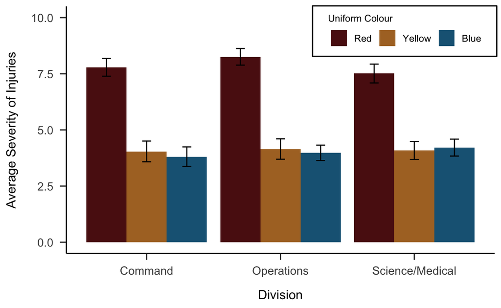

# Discussion

[figure not shown]

Figure 4: Two science officers dawning a red Starfleet uniform (A). The result of said uniform on their lifespans (B).

## Limitations

Spock would like to remind our readers that, because their was no random assignment to division, this is not a true experiment. So our results should be taken with caution. Future studies building on the work here should consider randomly assigning participants both a uniform colour *and* division. Training exercises at Starfleet Academy would be an excellent candidate for such an experiment.

# Conclusion

It appears, after careful observation, that wearing a red Starfleet uniform during space exploration is bad for one’s health, often leading to an untimely demise. As a doctor who does not wish to become an undertaker, it is my recommendation that Starfleet investigate the cause(s) underlying red uniform’s effects on officer behaviour. To boldly go where no one has gone before.

## Open Science

The code and materials for analyzing data and generating the manuscript for this project are available in the project’s [GitHub repository](https://github.com/mccarthy-m-g/mccoy-and-spock-2287). This project was written using R version 4.0.3 (2020-10-10) (R Core Team, 2020) in RStudio version 1.4.1103 (RStudio Team, 2021). Statistical analyses were done using the `moments` (Komsta & Novomestky, 2015), `car` (Fox & Weisberg, 2019), `stats` (R Core Team, 2020), and `emmeans` (Lenth, 2021) R packages. To easily inspect the intermediate output of data analysis code pipes from this manuscript, we suggest using the `boomer` (Fabri, 2021) R package. All packages and dependencies used in this project can be seen in Table 2:

Table 2: All Packages and Dependencies for this Project (Scrollable).

| Package | Version | Source |
| --- | --- | --- |
| BH | 1.75.0-0 | CRAN |
| DBI | 1.1.1 | CRAN |
| Formula | 1.2-4 | CRAN |
| Hmisc | 4.4-2 | CRAN |
| MASS | 7.3-53 | CRAN |
| Matrix | 1.3-2 | CRAN |
| MatrixModels | 0.4-1 | CRAN |
| R6 | 2.5.0 | CRAN |
| RColorBrewer | 1.1-2 | CRAN |
| Rcpp | 1.0.6 | CRAN |
| RcppArmadillo | 0.10.1.2.2 | CRAN |
| RcppEigen | 0.3.3.9.1 | CRAN |
| SparseM | 1.78 | CRAN |
| abind | 1.4-5 | CRAN |
| askpass | 1.1 | CRAN |
| assertthat | 0.2.1 | CRAN |
| backports | 1.2.1 | CRAN |
| base64enc | 0.1-3 | CRAN |
| bayestestR | 0.8.2 | CRAN |
| blob | 1.2.1 | CRAN |
| bookdown | 0.21 | CRAN |
| boomer | 0.0.0.9000 | NULL |
| boot | 1.3-26 | CRAN |
| brio | 1.1.1 | CRAN |
| broom | 0.7.4 | CRAN |
| callr | 3.5.1 | CRAN |
| car | 3.0-10 | CRAN |
| carData | 3.0-4 | CRAN |
| cellranger | 1.1.0 | CRAN |
| checkmate | 2.0.0 | CRAN |

[output cut: 129 more lines]

## Author Contributions

McCoy came up with the idea for this experiment and conducted all data collection and analysis. McCoy and Spock wrote this paper, however, Spock’s main contribution was merely questioning McCoy’s logic.

## Fair Dealing

Any of the trademarks, service marks, collective marks, design rights or similar rights that are mentioned, used, or cited in this manuscript are the property of their respective owners. They are used here as fair dealing for the purpose of education, parody, and satire in accordance with [section 29 of the Copyright Act](https://laws-lois.justice.gc.ca/eng/acts/c-42/page-8.html#h-103270) and do not infringe copyright.

Fabri, A. (2021). *Boomer: Print the output of intermediate steps of a call*. https://github.com/moodymudskipper/boomer

Fox, J., & Weisberg, S. (2019). *An R companion to applied regression* (Third). Sage. https://socialsciences.mcmaster.ca/jfox/Books/Companion/

Komsta, L., & Novomestky, F. (2015). *Moments: Moments, cumulants, skewness, kurtosis and related tests*. https://CRAN.R-project.org/package=moments

Lenth, R. V. (2021). *Emmeans: Estimated marginal means, aka least-squares means*. https://CRAN.R-project.org/package=emmeans

McCoy, L. H. (5327). *Medical log, stardate 5327.4*. USS Enterprise (NCC-1701).

Mudd, H. F. (2266). *Statistical assumptions, who needs them?* Mudd Publishing.

Phlox. (2153). Classifying common medical maladies in humans during space exploration. *Starfleet Journal of Medicine*, *1*(1), 11–48.

R Core Team. (2020). *R: A language and environment for statistical computing*. R Foundation for Statistical Computing. https://www.R-project.org/

RStudio Team. (2021). *RStudio: Integrated development environment for r*. RStudio, PBC. http://www.rstudio.com/

Spock, S. T. (2287). *Personal communication*. USS Enterprise (NCC-1701).

[^1]: The USS Enterprise (NCC-1701), a Constitution-class starship launched by Starfleet in the year 2245.
[^2]: A Klingon’s worst nightmare.